# Web Design 101

TUJ Fall 2020

# Meaningful Interactions with Javascript

#### Today’s Agenda

- **Review**
- JavaScript Practice
- break
- Meaningful interactions
- Understanding Forms

# Review

What is HTML?

HyperText Markup Language

What do we use HTML for?

To define the **structure** of our content.

What is CSS?

Cascading Style Sheets

What do we use CSS for?

To define the **presentation** of our content.

What are personas?

*fictional* characters that help us target our *ideal* users

To write CSS, you define **rules**. What are the 4 parts of a css rule?

- selector
- declaration
- property
- value

```css
h1 {
  color: cornflowerblue;
  font-size: 16px;
}
```

`h1` is the __________.

`color` and `font-size` are _______.

`cornflowerblue` and `16px` are _______.

`h1` is the **selector**.

`color` and `font-size` are **properties**.

`cornflowerblue` and `16px` are **values**.

Name 4 techniques for creating focus on an element in your design.

- movement / animation
- bright colors
- circles & curves
- scale: make your element large

How do we make a visual composition feel “pleasing”?

We make sure it has **balance**, whether it is symmetrical or asymmetrical.

What does this image represent?

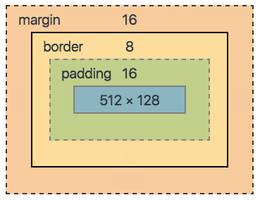

**CSS Box Model**

- content
- padding
- border
- margin

If HTML controls the **structure** of our web page and CSS controls the **presentation**, what do we use to control **interaction**?

JavaScript

# Practice

stackblitz.com/fork/js-tuj-practice

# Meaningful interactions

## Pop-ups

Are they ever good?

Features:

- hard to miss
- are triggered after a user begins interacting
- important (like ⚠️ warning messages)
- can be personalized
- opportunities for creativity

### Use with caution

- intrusive
- hard to close
- boring
- confusing

## Forms

When do you need one?

When you want to get information from your users.

When you would like users to *give* you some information.

## Who do we design for?

Humans / Users

Awkward social interactions aren’t limited to parties.

[figure not shown]

Web design is about communication and relationship building.

Forms are about trust and value.

## Forms in HTML

```html
<form></form>
```

Forms should have all these parts:

- input fields or text areas for collecting data
- labels for your input fields (usability)
- a submit button

```html
<input type="text" name="first-name" id="first-name" required />
```

- type helps with built-in browser helpers
- name attribute helps you organize the data you collect
- id is important for labels

#### some input types

- checkbox
- date
- email
- password
- radio
- text
- hidden

### textarea

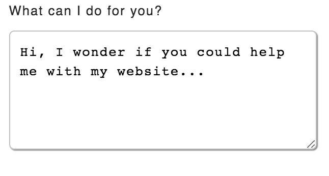

```html
<label for="message">What can I do for you?</label>
<textarea name="message" id="message" rows=5 />
```

### label

`<label>` - describes the input field for the user

```html
<label for="first-name">First name</label>
```

```html
<input type="text" name="first-name" id="first-name" required />
```

### submit button

```html
<button type="submit"> Send my message</button>
```

## What do you do with form data?

- Use it immediately to update the page
- Store it for use later

What do you need to be able to collect form data?

JavaScript

stackblitz.com/fork/tuj-form-practice

# Netlify simplifies

```html
<form name="my-form" data-netlify="true">
```